# Advanced Empirical Finance: Topics and Data Science

Market microstructure and high-frequency data

Stefan Voigt

University of Copenhagen and Danish Finance Institute (DFI)

Spring 2027

## Today

- How a stock trades: the limit order book
- High-frequency data: LOBSTER and SPY
- Liquidity and price impact

## From monthly returns to every order

- **So far:** monthly returns, one number per stock and month
- **Today:** every order that reaches the exchange, time-stamped to the nanosecond. Billions of messages a day across US stocks
- **Why:** trading costs (lecture 5 and the trading game), volatility measured within the day (lecture 17), covariances for portfolio choice (lecture 18)

Assignment 3 on realized volatility from high-frequency data starts today

# The limit order book

## Whiteboard: the limit order book

An exchange collects orders to buy and to sell. Which trades happen, and at which prices?

- **Limit order:** buy or sell up to a quantity at a stated price or better. Waits in the **order book** until it is executed or cancelled
- **Market order:** buy or sell a quantity now, at the best prices in the book
- **Best bid and best ask:** the highest buy and the lowest sell price. **Spread:** their difference; **midquote:** their average. **Depth:** the quantity waiting at a price
- **Price-time priority:** better prices first, at the same price the older order first
- A large market order walks up the book: it pays more than the best price, its **price impact**

## An order book

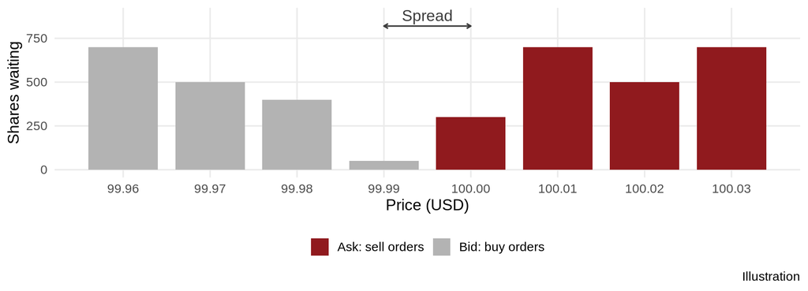

- A market order to buy 1,000 shares takes 300 at 100.00 and 700 at 100.01: it clears both levels and moves the best ask up by two cents, to 100.02

## A NASDAQ trading day

**Opening auction**

**Continuous trading**: submissions, cancellations, executions; visible and hidden orders

**Closing auction**

**After-hours trading**

- Most of the trading volume of a US stock is not on its listing exchange: a stock listed on the NYSE also trades on NASDAQ and many other venues

# High-frequency data

## LOBSTER: the terms of the data

- [LOBSTER](https://lobsterdata.com) rebuilds the NASDAQ order book of any stock from the exchange’s messages; KU has access
- **Message file:** one row per event: time (seconds after midnight, with nanoseconds), event type, order ID, size, price, direction (buy or sell)
- **Event types:** submission of a new limit order, partial cancellation, deletion, execution of a visible order, execution of a hidden order, auction trade, trading halt
- **Order book file:** after every event, the best prices and the depth on each side, for as many levels as requested
- One stock and one day easily have millions of messages: the data are aggregated before we use them

## The SPY data

- R
- Python

```r
# Five-second snapshots of the SPY order book during regular trading hours,
# for one month in every year
spy <- map(years, \(year) {
  start <- make_date(year, sample_month, 1)
  download_data(
    domain = "Tidy Finance", dataset = "high_frequency_sp500",
    start_date = start, end_date = ceiling_date(start, "month") - days(1)
  ) |>
    mutate(year = year)
}) |>
  bind_rows()
```

```python
# Five-second snapshots of the SPY order book during regular trading hours,
# for one month in every year
spy = pl.concat([
    tf.download_data(domain="Tidy Finance", dataset="high_frequency_sp500",
                     start_date=f"{year}-03-01", end_date=f"{year}-03-31")
    .with_columns(year=pl.lit(year))
    for year in range(2008, 2026)
])
```

- SPY, the ETF on the S&P 500, on NASDAQ from July 2007, built from LOBSTER: every 5 seconds the midquote, the **spread** (basis points of the midquote), the **depth** at the best quotes and within 5 bps (shares), the **dollar volume** traded, and the **signed order flow** (buyer- minus seller-initiated shares)
- Here: March of every year 2008–2025, 1,815,840 snapshots

## Liquidity through the day

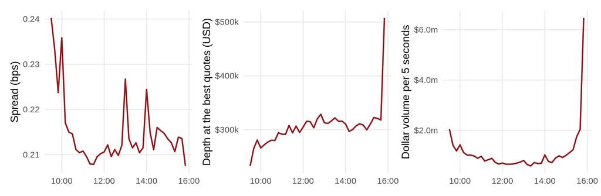

- March 2024, averages per ten minutes of continuous trading (without the opening and closing auctions): trading is heaviest at the open and at the close (the U-shape); the spread is widest right after the open, when uncertainty is largest, and depth builds up during the day

## Liquidity over the years

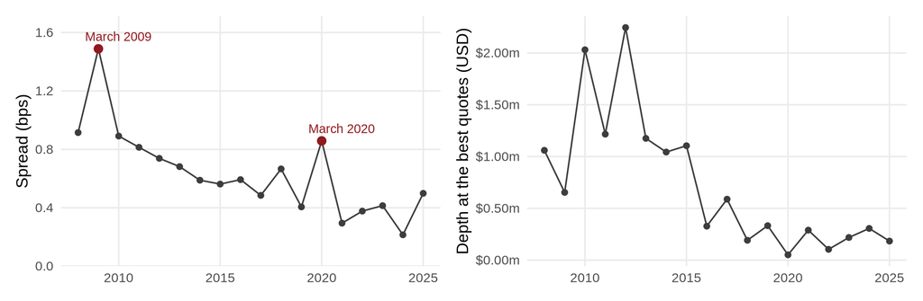

- The spread fell from 0.91 bps in March 2008 to 0.21 bps in March 2024: SPY trades at the minimum tick of one cent, which became ever smaller relative to the price. Crises widen it: March 2009 and March 2020
- Depth at the best quotes shrank as well, with smaller orders spread over more trading venues

# Price impact

## Whiteboard: price impact

Kyle (1985): a market maker sees only the total order flow $x$, from informed and uninformed traders. Which price does she set?

$$p = E[v \mid x] = p_0 + \lambda\, x \qquad \text{with} \qquad \lambda = \frac{\text{Cov}(v, x)}{\text{Var}(x)}$$

- Buying pushes the price up because buying may be informed. $\lambda$ measures illiquidity: the larger, the more a trade moves the price
- A trade of size $q$ costs about $\lambda q \cdot q$: costs grow with the square of the trade, the **quadratic costs** of lecture 5

## Price impact in code

- R
- Python

```r
# One-minute midquote returns (bps) on one-minute net buying in USD million:
# signed shares times the midquote of their snapshot
price_impact <- spy |>
  mutate(day = as_date(ts), minute = floor_date(ts, "minute")) |>
  summarize(
    midquote = last(midquote), flow = sum(signed_volume * midquote) / 1e6,
    .by = c(year, day, minute)
  ) |>
  mutate(ret = 1e4 * (log(midquote) - lag(log(midquote))), .by = c(year, day)) |>
  drop_na() |>
  nest(data = -year) |>
  mutate(
    fit = map(data, \(d) lm(ret ~ flow, data = d)),
    lambda = map_dbl(fit, \(f) coef(f)[["flow"]]),
    r2 = map_dbl(fit, \(f) summary(f)$r.squared)
  )
```

```python
# One-minute midquote returns (bps) on one-minute net buying in USD million:
# signed shares times the midquote of their snapshot
minutes = (spy
    .with_columns(day=pl.col("ts").dt.date(), minute=pl.col("ts").dt.truncate("1m"))
    .group_by("year", "day", "minute", maintain_order=True)
    .agg(midquote=pl.col("midquote").last(),
         flow=(pl.col("signed_volume") * pl.col("midquote")).sum() / 1e6)
    .sort("year", "day", "minute")
    .with_columns(ret=1e4 * pl.col("midquote").log().diff().over("year", "day"))
    .drop_nulls())
price_impact = (minutes.group_by("year")
    .agg(lambda_=pl.cov("ret", "flow") / pl.col("flow").var(),
         r2=pl.corr("ret", "flow") ** 2)
    .sort("year"))
```

The slope of a regression of returns on order flow estimates $\lambda$, here in basis points per USD 1 million of net buying in a minute

## Price impact over the years

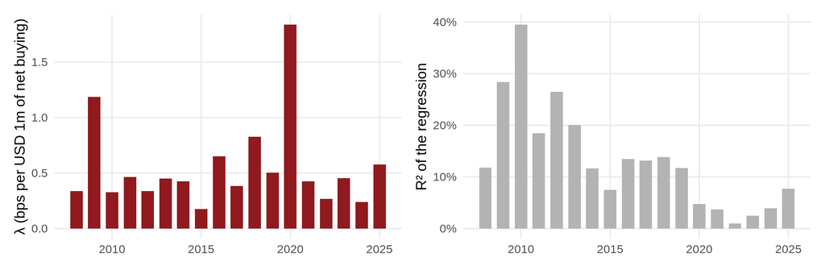

- Net buying of USD 1 million in a minute moved SPY by 0.34 bps in March 2008 and by 0.24 bps in March 2024. It moved it most in March 2009 and March 2020
- Order flow explains less and less of the minute’s return: more of the price moves without trading, as quotes update on news and on other venues

## Whiteboard: the bid-ask bounce

Roll (1984): the true price follows a random walk, but each trade happens at the bid or at the ask, with equal probability. What does that do to trade price changes?

$$p_t = m_t + \frac{s}{2} q_t, \quad q_t = \pm 1 \qquad \Longrightarrow \qquad \text{Cov}(\Delta p_t, \Delta p_{t-1}) = -\frac{s^2}{4}$$

- Trade prices bounce between bid and ask: their changes are negatively autocorrelated, and the spread follows as $s = 2\sqrt{-\text{Cov}(\Delta p_t, \Delta p_{t-1})}$
- The bounce adds variance that is not in the true price. The more often we sample, the more of it we measure: **microstructure noise**, the topic of lecture 17